# Línea de tiempo - Transmisibilidad del Sars-Cov2

Desde el inicio de la pandemia de COVID-19 en 2019, el virus SARS-CoV-2 ha acumulado mutaciones que han dado lugar a múltiples variantes con distintos grados de transmisibilidad y evasión inmunológica. Entre los genes virales, el gen S, que codifica la proteína Spike, ha sido uno de los más estudiados, ya que permite la entrada del virus a las células humanas a través del receptor ACE2. El seguimiento de las mutaciones en el gen S permite identificar qué cambios pueden afectar la eficacia de las vacunas actuales, así como anticipar la aparición de variantes con potencial de generar nuevas olas epidémicas. Por ello, es crucial monitorear continuamente su evolución genética y funcional.

Nuestro objetivo como investigadores, es establecer una línea de tiempo sobre **qué es exactamente lo que ha hecho al virus tan infeccioso**, enfocándonos en las mutaciones del gen en cuestión.

## Marco teórico

Diversos estudios han demostrado que el SARS-CoV-2 comparte más del 96% de su genoma con coronavirus de murciélagos, y que su linaje probablemente se separó de su ancestro más cercano RaTG13 hace entre 40 y 70 años. Esta historia evolutiva sugiere que existen múltiples linajes zoonóticos (grupo específico dentro de un linaje evolutivo en animales con la capacidad de causar infecciones en humanos o viceversa) aún no muestreados, con potencial de emerger en humanos. La proteína Spike es una glicoproteína de membrana dividida en dos subunidades: S1, que contiene el dominio de unión al receptor (RBD), y S2, responsable de la fusión de la membrana viral con la célula hospedadora. Las mutaciones en S1, especialmente en el RBD, son de particular interés, ya que pueden aumentar la afinidad por ACE2 o permitir escape inmune. A lo largo de la pandemia, variantes como Delta y Ómicron han acumulado múltiples mutaciones no sinónimas en esta región, lo que se ha traducido en una mayor capacidad de transmisión, así como una reducción en la neutralización por anticuerpos generados por infecciones previas o vacunas. La vigilancia de estas mutaciones proporciona un panorama sobre la adaptabilidad del virus y su potencial pandémico.

## Hipótesis

Se espera encontrar que las variantes más recientes, como las subvariantes de Ómicron, presentan un mayor número de mutaciones no sinónimas en el gen S, especialmente en regiones críticas como el dominio RBD, en comparación con variantes anteriores como Alfa o Beta. Estas mutaciones probablemente están asociadas con una mayor capacidad de transmisión y una mayor evasión de la respuesta inmune, lo que explicaría su predominio en las olas más recientes de contagio.

## Wuhan - La mutación que desencadenó una pandemia

El virus Sars-Cov2 se originó a partir de su variante antecesora llamada RaTG13. El cambio clave que generó una gran afinidad al receptor humano ACE2, fue causado por un mecanismo llamado recombinación, que causó dos sustituciones clave: **S427N** y **F436Y**.

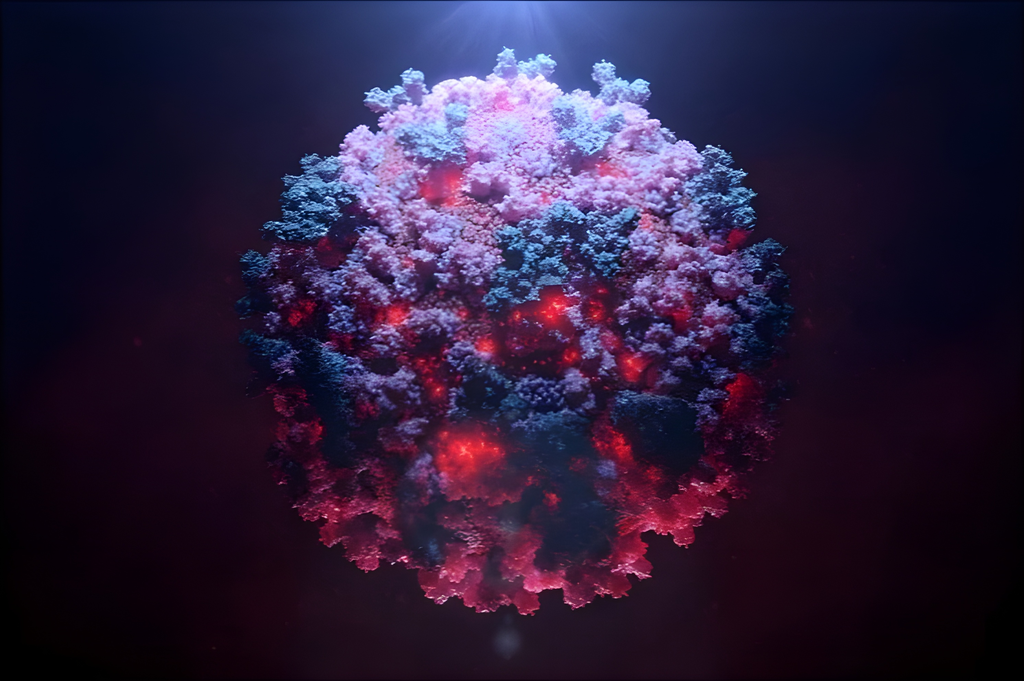

## Alpha - 40%-90% más transmisible

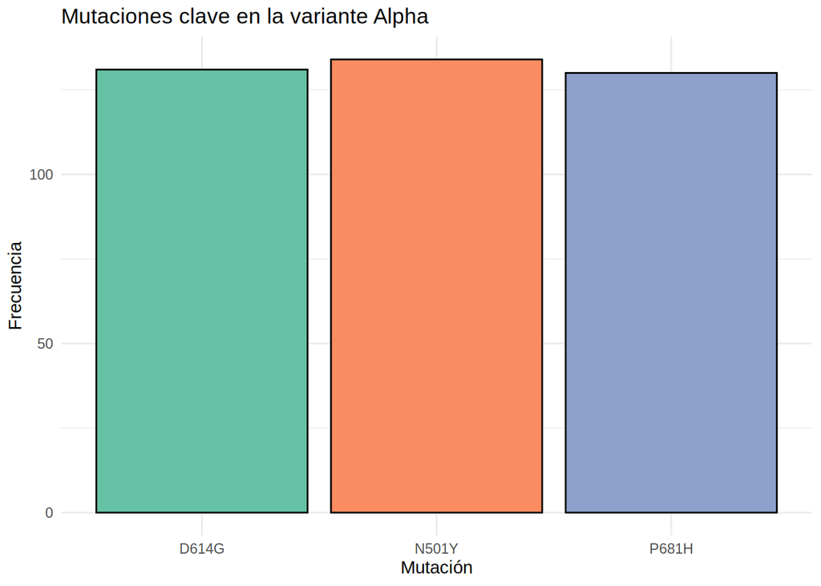

```r
key_mutations <- c("N501Y", "P681H", "D614G")

alpha_freqs <- mutations %>%
  filter(variant == "alpha", aa_change %in% key_mutations) %>%
  count(aa_change, name = "frequency")


ggplot(alpha_freqs, aes(x = aa_change, y = frequency, fill = aa_change)) +
  geom_bar(stat = "identity", color = "black") +
  labs(
    title = "Mutaciones clave en la variante Alpha",
    x = "Mutación",
    y = "Frecuencia"
  ) +
  theme_minimal() +
  scale_fill_brewer(palette = "Set2") +
  theme(legend.position = "none")
```

- N501Y La mutación N501Y redujo el valor de afinidad (K<sub>D</sub>) de aproximadamente unos 80 nanomoles (nM) a ~8 nM, lo que significa que el virus se pega al receptor más fuerte y con más facilidad.
- P681H La mutación P681H ocurrió justo al lado del sitio de corte por furina (en la unión S1/S2 de la espícula), facilitando que la proteína Spike sea procesada más eficientemente por enzimas celulares, lo que acelera la entrada del virus en la célula.
- D614G La mutación D614G no está en el dominio de unión al receptor, pero estabiliza la forma abierta de la proteína Spike, lo que permite una mayor proporción de espículas funcionales y, por tanto, una producción viral más alta y mayor capacidad de infección.

## Beta - 20% - 30% más transmisible que Alpha

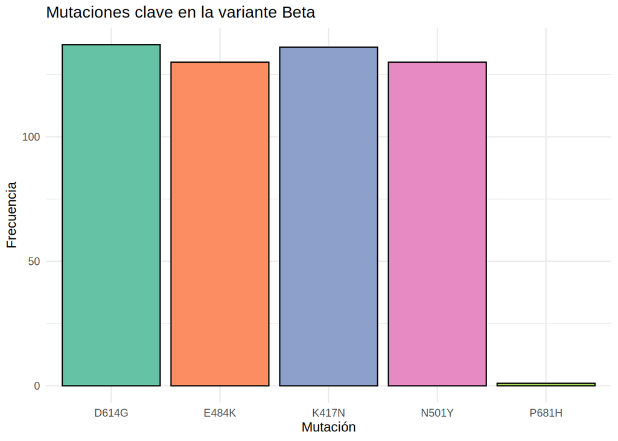

```r
key_mutations <- c("E484K", "K417N", "N501Y", "P681H", "D614G")

alpha_freqs <- mutations %>%
  filter(variant == "beta", aa_change %in% key_mutations) %>%
  count(aa_change, name = "frequency")


ggplot(alpha_freqs, aes(x = aa_change, y = frequency, fill = aa_change)) +
  geom_bar(stat = "identity", color = "black") +
  labs(
    title = "Mutaciones clave en la variante Beta",
    x = "Mutación",
    y = "Frecuencia"
    ) +
  theme_minimal() +
  scale_fill_brewer(palette = "Set2") +
  theme(legend.position = "none")
```

## Gamma – 30% - 40% más transmisible que Alpha

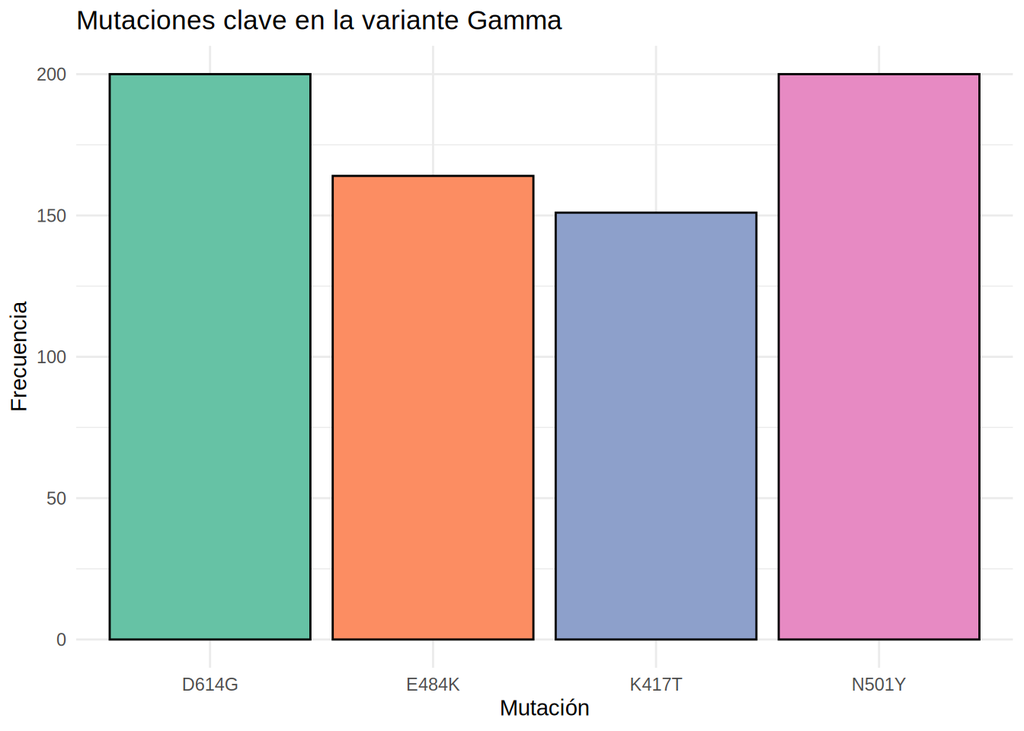

```r
key_mutations <- c("E484K", "K417T", "N501Y", "P681H", "D614G")

alpha_freqs <- mutations %>%
  filter(variant == "gamma", aa_change %in% key_mutations) %>%
  count(aa_change, name = "frequency")


ggplot(alpha_freqs, aes(x = aa_change, y = frequency, fill = aa_change)) +
  geom_bar(stat = "identity", color = "black") +
  labs(
    title = "Mutaciones clave en la variante Gamma",
    x = "Mutación",
    y = "Frecuencia"
  ) +
  theme_minimal() +
  scale_fill_brewer(palette = "Set2") +
  theme(legend.position = "none")
```

- Mismas mutaciones que Beta
- K417T Lisina -> Treonina Aunque por sí sola esta mutación podría disminuir ligeramente la unión a ACE2, en combinación con N501Y y E484K aumenta la unión al receptor y añade una barrera adicional frente a anticuerpos monoclonales

## Delta – 50% - 60% más transmisible que Alpha

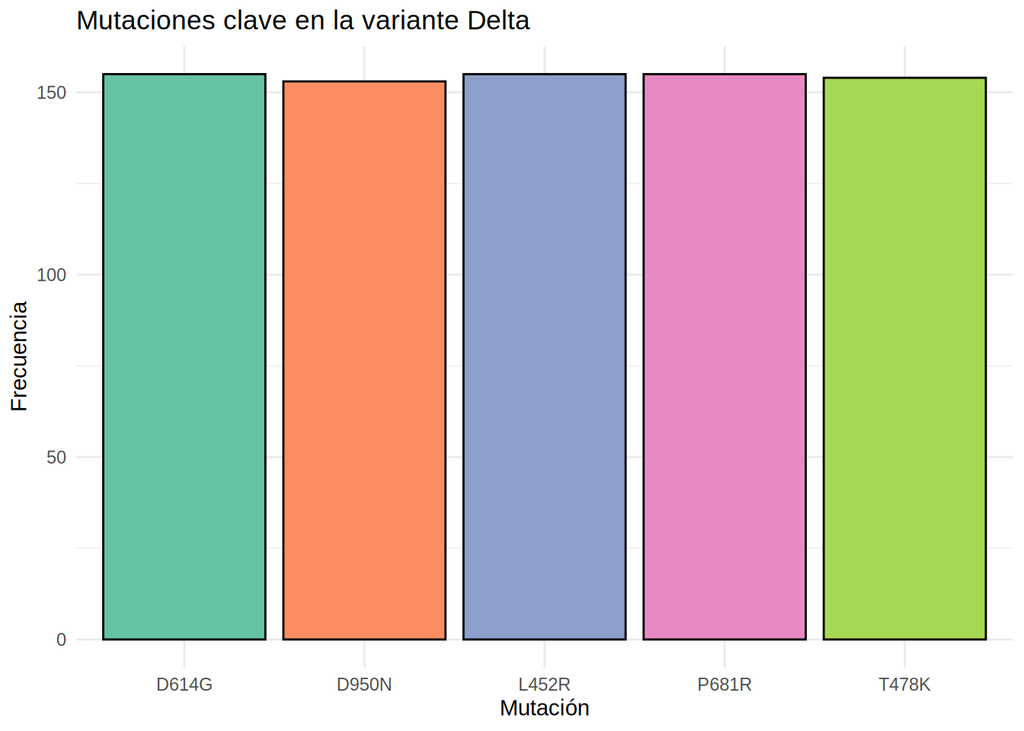

```r
key_mutations <- c("L452R", "T478K", "P681R", "D950N", "N501Y", "P681H", "D614G")

alpha_freqs <- mutations %>%
  filter(variant == "delta", aa_change %in% key_mutations) %>%
  count(aa_change, name = "frequency")


ggplot(alpha_freqs, aes(x = aa_change, y = frequency, fill = aa_change)) +
  geom_bar(stat = "identity", color = "black") +
  labs(
    title = "Mutaciones clave en la variante Delta",
    x = "Mutación",
    y = "Frecuencia"
  ) +
  theme_minimal() +
  scale_fill_brewer(palette = "Set2") +
  theme(legend.position = "none")
```

## Ómicron BA.1 – El doble o triple que Delta

[figure not shown]

```r
key_mutations <-  c(
  "A67V", "T95I", "G142D", "L212I",
  "G339D", "S371L", "S373P", "S375F", "K417N", "N440K", "G446S", "S477N", "T478K",
  "E484A", "Q493R", "G496S", "Q498R", "N501Y", "Y505H",
  "T547K", "D614G", "H655Y", "N679K", "P681H",
  "N764K", "D796Y", "N856K", "Q954H", "N969K", "L981F"
)

alpha_freqs <- mutations %>%
  filter(variant == "omicronba2", aa_change %in% key_mutations) %>%
  count(aa_change, name = "frequency")


ggplot(alpha_freqs, aes(x = aa_change, y = frequency, fill = aa_change)) +
  geom_bar(stat = "identity", color = "black") +
  labs(
    title = "Mutaciones clave en la variante Ómicron BA.1",
    x = "Mutación",
    y = "Frecuencia"
  ) +
  theme_minimal() +
  scale_fill_brewer(palette = "Set2") +
  theme(
    legend.position = "none",
    axis.text.x = element_text(angle = 45, hjust = 1, vjust = 1)  # Rotate 45°, adjust alignment
  )
```

## Ómicron BA.2 - 30% más que BA.1

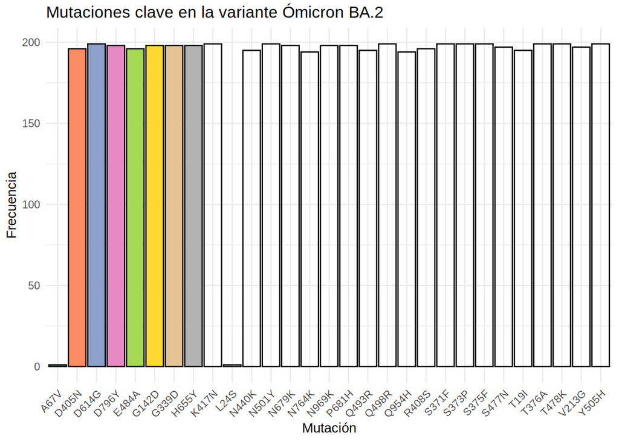

```r
key_mutations <-  c(
  "A67V", "T95I", "G142D", "G339D", "S371F", "S373P", "S375F",
  "K417N", "N440K", "S477N", "T478K", "E484A", "Q493R",
  "Q498R", "N501Y", "Y505H", "D614G", "H655Y", "N679K",
  "P681H", "N764K", "D796Y", "Q954H", "N969K", "L981F",

  "T19I", "L24S", "V213G", "T376A", "D405N", "R408S", "S704L"
)

alpha_freqs <- mutations %>%
  filter(variant == "omicronba2", aa_change %in% key_mutations) %>%
  count(aa_change, name = "frequency")


ggplot(alpha_freqs, aes(x = aa_change, y = frequency, fill = aa_change)) +
  geom_bar(stat = "identity", color = "black") +
  labs(
    title = "Mutaciones clave en la variante Ómicron BA.2",
    x = "Mutación",
    y = "Frecuencia"
  ) +
  theme_minimal() +
  scale_fill_brewer(palette = "Set2") +
  theme(
    legend.position = "none",
    axis.text.x = element_text(angle = 45, hjust = 1, vjust = 1)  # Rotate 45°, adjust alignment
  )
```

## Ómicron JN.1

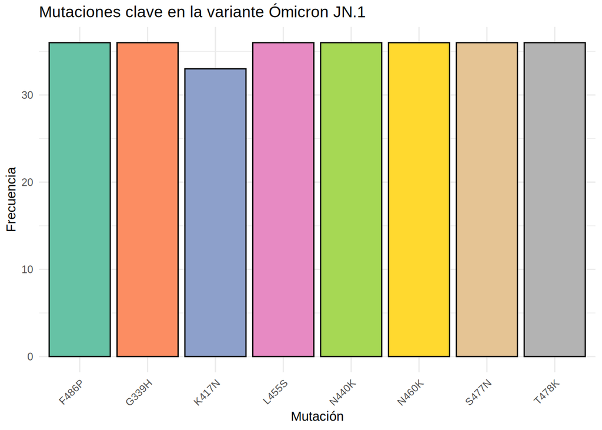

```r
key_mutations <- c(
  "V213E",
  "R493Q",
  "D574V",
  "F486P",
  "R346T",
  "L455S",
  "F456L",
  "G339H",
  "N460K",
    "K417N", "N440K", "S477N", "T478K", "E484A", "Q493R"

)

alpha_freqs <- mutations %>%
  filter(variant == "omicronjn1", aa_change %in% key_mutations) %>%
  count(aa_change, name = "frequency")


ggplot(alpha_freqs, aes(x = aa_change, y = frequency, fill = aa_change)) +
  geom_bar(stat = "identity", color = "black") +
  labs(
    title = "Mutaciones clave en la variante Ómicron JN.1",
    x = "Mutación",
    y = "Frecuencia"
  ) +
  theme_minimal() +
  scale_fill_brewer(palette = "Set2") +
  theme(
    legend.position = "none",
    axis.text.x = element_text(angle = 45, hjust = 1, vjust = 1)
  )
```

### **Datos Curiosos**

1. **XBB fue el primer recombinante global**: Apareció en **2022** y obligó a actualizar vacunas. Mezcla de BA.2.10.1 y BA.2.75
2. **JN.1 tuvo una ventaja oculta**: La mutación `L455S` era **invisible** a tests PCR comunes.
3. **BA.2.75 (uno de los “padres” de XBB)**: Fue apodado **“Centaurus”** por su rápida expansión en India.
4. **XBB.1.5**: Subvariante de XBB con **F486P mejorada**, dominó EE.UU. en 2023.

# Variantes que utilizan receptores distintos a hACE2

Después de la investigación descubrimos que ninguna variante de Sars-CoV-2 utiliza un receptor distinto como receptor principal, sin embargo hay estudios que sugieren que algunas variantes, como Delta y Ómicron, han tenido mutaciones que permiten utilizar otros receptores, principalmente el receptor Neuropilina (NRP1). Las mutaciones específicas son: * Delta: P681R -> Corte de furina * Ómicron BA.1 -> La deleción Δ69-70 podría permitir infectar células incluso cuando ACE2 está bloqueado por anticuerpos.